# DS C41 | Clustering Live Coding Session | Slot 2 | 23 July 2022

## K-Means Clustering with Scikit-Learn

K-means clustering is one of the most widely used unsupervised machine learning algorithms that forms clusters of data based on the similarity between data instances. For this particular algorithm to work, the number of clusters has to be defined beforehand. The K in the K-means refers to the number of clusters.

The K-means algorithm starts by randomly choosing a centroid value for each cluster. After that the algorithm iteratively performs three steps:

(i) Find the Euclidean distance between each data instance and centroids of all the clusters;

(ii) Assign the data instances to the cluster of the centroid with nearest distance;

(iii) Calculate new centroid values based on the mean values of the coordinates of all the data instances from the corresponding cluster.

## A Simple Example

Let's try to see how the K-means algorithm works with the help of a handcrafted example, before implementing the algorithm in Scikit-Learn.

We have a set of the following two dimensional data instances named D.

```python
D = { (5,3), (10,15), (15,12), (24,10), (30,45), (85,70), (71,80), (60,78), (55,52), (80,91) }

# We want to divide this data into two clusters,
# C1 and C2 based on the similarity between the data points.
```

The first step is to randomly initialize values for the centroids of both clusters. Let's name centroids of clusters C1 and C2 as c1 and c2 and initialize them with the values of the first two data points i.e. (5, 3) and (10, 15).

[figure not shown]

After assigning data points to the corresponding clusters, the next step is to calculate the new centroid values. These values are calculated by finding the means of the coordinates of the data points that belong to a particular cluster.

For cluster C1, there is currently only one point i.e. (5,3), therefore the mean of the coordinates remain same and the new centroid value for c1 will also be (5,3).

For C2, there are currently 9 data points. We name the coordinates of data points as x and y. The new value for x coordinate of centroid c2 can be calculated by determining the mean of x coordinates of all 9 points that belong to cluster C2 as given below:

c2(x) = (10 + 15 + 24 + 30 + 85 + 71 + 60 + 55 + 80) / 9 = 47.77  
The new value for y coordinate of centroid c2 can be calculated by determining the mean of all y coordinates of all 9 points that belong to cluster C2.

c2(y) = (15 + 12 + 10 + 45 + 70 + 80 + 78 + 52 + 91) / 9 = 50.33

**The updated centroid value for c2 will now be {47.77, 50.33}.

For the next iteration, the new centroid values for c1 and c2 will be used and the whole process will be repeated. The iterations continue until the centroid values stop updating.

[figure not shown]

c1(x) = (5, 10, 15, 24) / 4 = 13.5  
c1(y) = (3, 15, 12, 10) / 4 = 10.0 **Updated c1 to be (13.5, 10.0).

c2(x) = (30 + 85 + 71 + 60 + 55 + 80) / 6 = 63.5  
c2(y) = (45 + 70 + 80 + 78 + 52 +91) / 6 = 69.33  
**Updated c2 to be (63.5, 69.33).

[figure not shown]

c1(x) = (5, 10, 15, 24, 30) / 5 = 16.8  
c1(y) = (3, 15, 12, 10, 45) / 5 = 17.0  
**Updated c1 to be (16.8, 17.0).

c2(x) = (85 + 71 + 60 + 55 + 80) / 5 = 70.2  
c2(y) = (70 + 80 + 78 + 52 + 91) / 5 = 74.2  
**Updated c2 to be (70.2, 74.2).

[figure not shown]

At the end of fourth iteration, the updated values of C1 and C2 are same as they were at the end of the third iteration. This means that data cannot be clustered any further. c1 and c2 are the centroids for C1 and C2. To classify a new data point, the distance between the data point and the centroids of the clusters is calculated. Data point is assigned to the cluster whose centroid is closest to the data point.

## K-means Clustering with Scikit-Learn

Now that we know how the K-means clustering algorithm actually works, let's see how we can implement it with Scikit-Learn.

```python
import numpy as np
import pandas as pd
import matplotlib.pyplot as plt
import seaborn as sns

import warnings
warnings.filterwarnings("ignore")
```

```python
X = np.array([
    (5,3), (10,15), (15,12), (24,10), (30,45), (85,70), (71,80), (60,78), (55,52), (80,91)
])
print(X)
```

```
[[ 5  3]
 [10 15]
 [15 12]
 [24 10]
 [30 45]
 [85 70]
 [71 80]
 [60 78]
 [55 52]
 [80 91]]
```

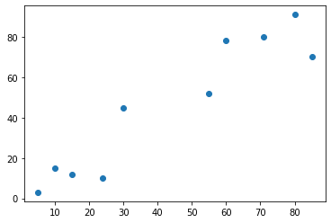

```python
plt.scatter(X[:,0], X[:,1])
plt.show()
```

```python
from sklearn.cluster import KMeans
```

```python
# Create Clusters. Assume the number of clusters = 2

kmeans = KMeans(n_clusters=2)
kmeans.fit(X)
```

```
KMeans(n_clusters=2)
```

```python
kmeans.cluster_centers_
```

```
array([[70.2, 74.2],
       [16.8, 17. ]])
```

```python
kmeans.labels_
```

```
array([1, 1, 1, 1, 1, 0, 0, 0, 0, 0], dtype=int32)
```

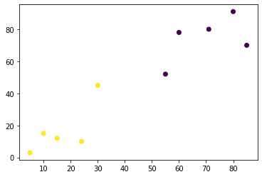

```python
plt.scatter(X[:,0], X[:,1], c= kmeans.labels_)
plt.show()
```

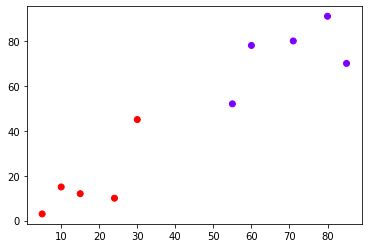

```python
plt.scatter(X[:,0], X[:,1], c= kmeans.labels_, cmap='rainbow')
plt.show()
```

```python
kmeans.cluster_centers_
```

```
array([[70.2, 74.2],
       [16.8, 17. ]])
```

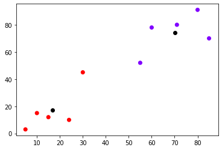

```python
plt.scatter(X[:,0], X[:,1], c= kmeans.labels_, cmap='rainbow')
plt.scatter(kmeans.cluster_centers_[:,0], kmeans.cluster_centers_[:,1], c= 'black')
plt.show()
```

```python
# Create Clusters. Assume the number of clusters = 3

kmeans = KMeans(n_clusters=3)
kmeans.fit(X)
```

```
KMeans(n_clusters=3)
```

```python
kmeans.cluster_centers_
```

```
array([[42.5 , 48.5 ],
       [74.  , 79.75],
       [13.5 , 10.  ]])
```

```python
kmeans.labels_
```

```
array([2, 2, 2, 2, 0, 1, 1, 1, 0, 1], dtype=int32)
```

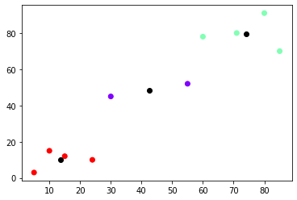

```python
plt.scatter(X[:,0], X[:,1], c= kmeans.labels_, cmap='rainbow')
plt.scatter(kmeans.cluster_centers_[:,0], kmeans.cluster_centers_[:,1], c= 'black')
plt.show()
```